# Large Wood Impacts on Sediment Transport Following Wildfire

Alec Arditti

3/3/2021

# Overview

I am mapping woody debris (LW) over time in stream channels following wildfire. This spatial and temporal dataset will be applied in conjunction with geomorphic features to determine the location of sediment routing bottlenecks and which watersheds are more connected. These results will also be compared to an existing post-fire sediment routing model.

# Datasets

Fires dataset: These are past wildfires that will serve as study sites. These 18 sites have been selected on the basis of having variable slope steepness, coniferous cover and burn severity.

Satellite Imagery: This consists of Google and Hexagon available aerial imagery that will be used for analysis.Imagery was taken at different points along a 10 year period and varies in resolution and extent.

LW (large wood) dataset: LW features (jams and individual logs) will be stored in this dataset.Attributes of features will be recorded based on the aerial imagery and context of the burn severity as well as the valley bottom.

# Database Structure

LW (large wood) data will be collected for each fire based on available satellite imagery in different years. Each temporal point will consist of an LW dataset and these datasets will be compiled for each fire to comprise a database.

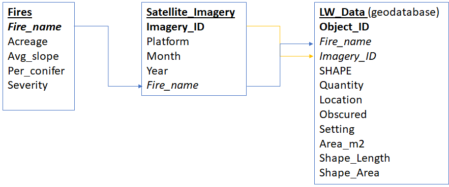

Figure 1- Database Schema

# Build the Database

First I will connect to the database:

```r
lw <- dbConnect(RSQLite::SQLite(), "C:/Users/BelmontLab/Documents/Alec/School/Spring 2021/Full Lifecycle of Data Management/R markdown assignment/lw.db")
```

Then I will add each dataset to the database and link them

1. Fires

```r
dbExecute(lw, "CREATE TABLE Fires (
Fire_name varchar(25) NOT NULL,
Acreage varchar(5),
Avg_slope varchar(5),
Per_conifer varchar(5),
Severity varchar(5),
PRIMARY KEY (Fire_name)
);")
```

2. Imagery

```r
dbExecute(lw, "CREATE TABLE Satellite_Imagery (
Imagery_ID varchar(2) NOT NULL,
Platform varchar(25),
Month varchar(10),
Year char(4),
Fire_name varchar(25),
PRIMARY KEY (Imagery_ID),
FOREIGN KEY (Fire_name) REFERENCES Fires(Fire_name)
);")
```

3. Large Wood

```r
dbExecute(lw, "CREATE TABLE LW_DATA (
Object_ID varchar(3) NOT NULL,
Fire_name varchar(25),
Imagery_ID varchar(2),
SHAPE char(5),
Quantity varchar(3),
Location varchar(20) CHECK (Location IN ('In Channel', 'Channel & Floodplain', 'Only in floodplain', 'Crosses entire channel')),
Obscured varchar(20) CHECK (Obscured IN ('No pieces obscured', 'Some pieces obscured',' Many pieces obscured')),
Setting varchar(20), CHECK (Setting IN ('Fluvial', 'Debris Flow'))
Area_m2 varchar(5),
Shape_Length varchar(5),
Shape_Area varchar(5),
PRIMARY KEY (Object_ID),
FOREIGN KEY (Fire_name) REFERENCES Fires(Fire_name)
FOREIGN KEY (Imagery_ID) REFERENCES Satellite_Imagery(Imagery_ID)
);")
```

> “That’s all folks!”